# Berkeley Earth Global Temperature Anomalies: Time Series Analysis

## Eviana Pham

### May 14 2026

This notebook analyzes monthly Berkeley Earth global land/ocean temperature anomalies from January 1850 through March 2026. The goal is to answer three main time-series questions, plus a forecasting model comparison:

1. Has the rate of warming changed over time?
2. Has the autocorrelation structure changed between the early and modern periods?
3. After removing the long-term trend, is there evidence of multi-year periodicity consistent with climate cycles such as ENSO?

```python
import warnings
warnings.filterwarnings('ignore')
#!pip install scikit-learn
from pathlib import Path

import numpy as np
import pandas as pd
import matplotlib.pyplot as plt
import matplotlib.ticker as ticker
from scipy import signal, stats
import itertools
from statsmodels.stats.diagnostic import acorr_ljungbox
from statsmodels.graphics.tsaplots import plot_acf, plot_pacf
from statsmodels.tsa.stattools import adfuller
from statsmodels.tsa.statespace.sarimax import SARIMAX
from statsmodels.tsa.statespace.structural import UnobservedComponents
from sklearn.metrics import mean_absolute_error, mean_squared_error

plt.style.use('seaborn-v0_8-whitegrid')
plt.rcParams.update({
    'figure.figsize': (11, 4.5),
    'axes.titlesize': 13,
    'axes.labelsize': 11,
    'legend.fontsize': 9,
    'xtick.labelsize': 9,
    'ytick.labelsize': 9,
})

PROJECT_DIR = Path.cwd()
DATA_PATH = PROJECT_DIR / 'Berk.comb.long.csv'
FIG_DIR = PROJECT_DIR / 'figures'
FIG_DIR.mkdir(exist_ok=True)
```

## 1. Data Cleaning

The raw CSV includes future placeholder rows with value -9999, these are removed before analysis. After cleaning, the dataset is a monthly series with no missing months.

```python
# read the raw CSV, skipping the first row which is a header, and assign column names
raw = pd.read_csv(DATA_PATH, skiprows=1, names=['date', 'anomaly'])
raw['date'] = pd.to_datetime(raw['date']) # convert date column to datetime
raw['anomaly'] = pd.to_numeric(raw['anomaly'], errors='coerce')

# Berkeley/NOAA file uses large negative placeholders for unfilled future months
# Remove these rows and reindex to a complete monthly series
df = raw.loc[raw['anomaly'] > -99].copy().reset_index(drop=True)
df = df.set_index('date').asfreq('MS')

print(f'Raw rows: {len(raw):,}')
print(f'Clean rows: {len(df):,}') # 2,115
print(f'Date range: {df.index.min().date()} to {df.index.max().date()}') # 1850-01-01 to 2026-03-01
print(f"Missing values after monthly reindexing: {df['anomaly'].isna().sum()}") # no missing values after reindexing
display(df.describe())

# summaries
annual = df['anomaly'].resample('YS').mean().to_frame('anomaly')
annual['year'] = annual.index.year
```

```
Raw rows: 2,124
Clean rows: 2,115
Date range: 1850-01-01 to 2026-03-01
Missing values after monthly reindexing: 0
```

|  | anomaly |
| --- | --- |
| count | 2115.000000 |
| mean | 0.035891 |
| std | 0.409087 |
| min | -0.799000 |
| 25% | -0.247500 |
| 50% | -0.062000 |
| 75% | 0.225000 |
| max | 1.477000 |

## 2. Visualization

The full series shows a non-stationary mean: the average anomaly changes over time. The annual mean is plotted on top of the monthly data to make the long-run pattern easier to see.

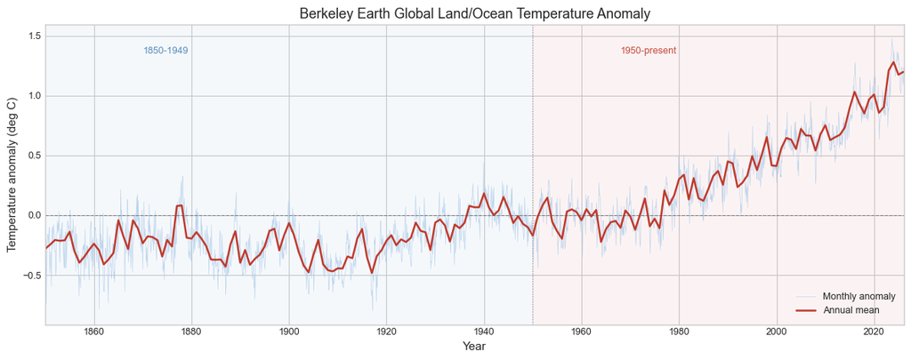

```python
fig, ax = plt.subplots(figsize=(12, 4.8))

ax.plot(df.index, df['anomaly'], color='#a8c8e8', linewidth=0.45, alpha=0.75, label='Monthly anomaly')
ax.plot(annual.index, annual['anomaly'], color='#c0392b', linewidth=1.8, label='Annual mean')

ax.axhline(0, color='#555', linewidth=0.8, linestyle='--', alpha=0.6)
ax.axvspan(df.index.min(), pd.Timestamp('1950-01-01'), alpha=0.05, color='steelblue')
ax.axvspan(pd.Timestamp('1950-01-01'), df.index.max(), alpha=0.05, color='firebrick')
ax.axvline(pd.Timestamp('1950-01-01'), color='#888', linewidth=0.9, linestyle=':', alpha=0.8)
ax.text(pd.Timestamp('1870-01-01'), 1.35, '1850-1949', fontsize=9, color='steelblue', alpha=0.9)
ax.text(pd.Timestamp('1968-01-01'), 1.35, '1950-present', fontsize=9, color='#c0392b', alpha=0.9)

ax.set_title('Berkeley Earth Global Land/Ocean Temperature Anomaly')
ax.set_xlabel('Year')
ax.set_ylabel('Temperature anomaly (deg C)')
ax.set_xlim(df.index.min(), df.index.max())
ax.yaxis.set_minor_locator(ticker.MultipleLocator(0.1))
ax.legend(loc='lower right', framealpha=0.9)
plt.tight_layout()
plt.savefig(FIG_DIR / '01_full_series.png', dpi=180, bbox_inches='tight')
plt.show()
```

## 3. Rolling Mean and Rolling Variability

Rolling summaries help separate long-run warming from short-run variability. A 10-year rolling mean shows slow changes in the average anomaly, while the rolling standard deviation shows whether variability changes over time.

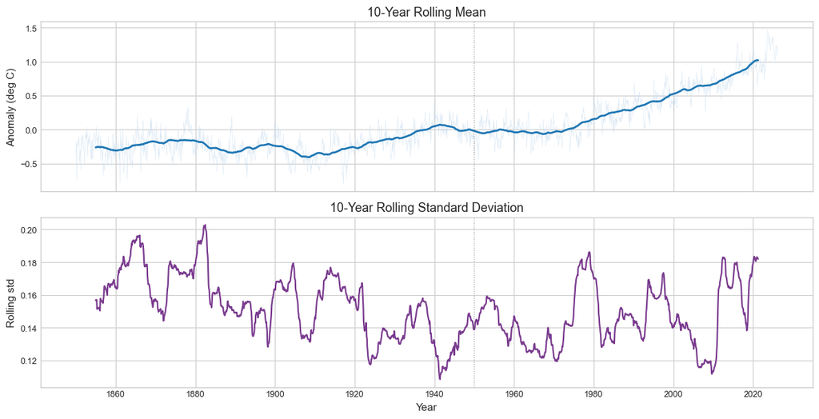

```python
rolling = pd.DataFrame({
    '10-year rolling mean': df['anomaly'].rolling(120, center=True).mean(),
    '10-year rolling std': df['anomaly'].rolling(120, center=True).std(),
})

fig, axes = plt.subplots(2, 1, figsize=(12, 6.2), sharex=True)
axes[0].plot(df.index, df['anomaly'], color='#c7dcef', linewidth=0.35, alpha=0.7)
axes[0].plot(rolling.index, rolling['10-year rolling mean'], color='#1f77b4', linewidth=2)
axes[0].set_ylabel('Anomaly (deg C)')
axes[0].set_title('10-Year Rolling Mean')

axes[1].plot(rolling.index, rolling['10-year rolling std'], color='#7a3b8f', linewidth=1.6)
axes[1].set_ylabel('Rolling std')
axes[1].set_xlabel('Year')
axes[1].set_title('10-Year Rolling Standard Deviation')

for ax in axes:
    ax.axvline(pd.Timestamp('1950-01-01'), color='#888', linewidth=0.9, linestyle=':', alpha=0.8)

plt.tight_layout()
plt.savefig(FIG_DIR / '02_rolling_summaries.png', dpi=180, bbox_inches='tight')
plt.show()
```

The rolling mean stays mostly below zero through the nineteenth and early twentieth centuries, meaning temperatures were generally cooler than the 1951–1980 baseline. After the late twentieth century, especially after about 1980, the rolling mean rises much more quickly. This supports the main trend result that the warming rate is not constant across the full record. The 10-year rolling standard deviation shows how much short-term variability changes over time. It fluctuates across the record rather than following one simple upward trend. There are periods of higher variability in both the early and modern parts of the series. This suggests that the main change in the data is the upward shift in the average temperature anomaly, while variability also changes over time but less smoothly.

## 4. Has the Warming Rate Changed?

A simple way to study changing warming rates is to fit linear trends to different eras. The slope is reported in degrees Celsius per decade so the results are interpretable.

|  | period | start | end | slope_degC_per_decade | stderr_per_decade | r_squared | p_value |
| --- | --- | --- | --- | --- | --- | --- | --- |
| 0 | Full record | 1850-01-01 | 2026-03-01 | 0.064166 | 0.001053 | 0.637177 | 0.000000e+00 |
| 1 | 1850-1949 | 1850-01-01 | 1949-12-01 | 0.021346 | 0.001834 | 0.101630 | 9.456421e-30 |
| 2 | 1950-present | 1950-01-01 | 2026-03-01 | 0.162891 | 0.002560 | 0.815932 | 0.000000e+00 |
| 3 | 1980-present | 1980-01-01 | 2026-03-01 | 0.206681 | 0.004704 | 0.777307 | 1.682032e-182 |

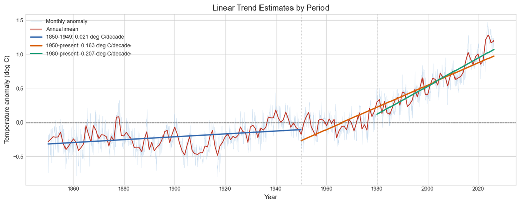

```python
trend_df = df.copy()
trend_df['year_decimal'] = trend_df.index.year + (trend_df.index.month - 1) / 12
trend_df['post_1950'] = (trend_df.index >= '1950-01-01').astype(int)
trend_df['post_1980'] = (trend_df.index >= '1980-01-01').astype(int)

def fit_linear_trend(data, label):
    """
    Fit a linear trend to the given data and return a dictionary of results.
    """
    x = data['year_decimal'].to_numpy()
    y = data['anomaly'].to_numpy()
    slope, intercept, r_value, p_value, stderr = stats.linregress(x, y) # slope is in deg C per year, multiply by 10 for per decade
    return {
        'period': label,
        'start': data.index.min().date(),
        'end': data.index.max().date(),
        'slope_degC_per_decade': slope * 10,
        'stderr_per_decade': stderr * 10,
        'r_squared': r_value**2,
        'p_value': p_value,
        'intercept': intercept,
        'slope': slope,
    }

# separate trend estimates for different periods to show how the warming rate changes over time
periods = {
    'Full record': trend_df,
    '1850-1949': trend_df.loc[:'1949-12-01'],
    '1950-present': trend_df.loc['1950-01-01':],
    '1980-present': trend_df.loc['1980-01-01':],
}

trend_results = pd.DataFrame([fit_linear_trend(data, label) for label, data in periods.items()])
display(trend_results[['period', 'start', 'end', 'slope_degC_per_decade', 'stderr_per_decade', 'r_squared', 'p_value']])

# plot the monthly anomalies, annual means, and fitted trend lines for each period
fig, ax = plt.subplots(figsize=(12, 4.8))
ax.plot(df.index, df['anomaly'], color='#b8d2ea', linewidth=0.45, alpha=0.7, label='Monthly anomaly')
ax.plot(annual.index, annual['anomaly'], color='#c0392b', linewidth=1.4, label='Annual mean')

colors = {'1850-1949': '#386cb0', '1950-present': '#d95f02', '1980-present': '#1b9e77'}
for row in trend_results.loc[trend_results['period'].isin(colors)].itertuples():
    sub = periods[row.period]
    fitted = row.intercept + row.slope * sub['year_decimal']
    ax.plot(sub.index, fitted, color=colors[row.period], linewidth=2.2,
            label=f'{row.period}: {row.slope_degC_per_decade:.3f} deg C/decade')

ax.axhline(0, color='#555', linewidth=0.8, linestyle='--', alpha=0.5)
ax.axvline(pd.Timestamp('1950-01-01'), color='#888', linewidth=0.9, linestyle=':', alpha=0.8)
ax.axvline(pd.Timestamp('1980-01-01'), color='#888', linewidth=0.9, linestyle=':', alpha=0.8)
ax.set_title('Linear Trend Estimates by Period')
ax.set_xlabel('Year')
ax.set_ylabel('Temperature anomaly (deg C)')
ax.legend(loc='upper left', framealpha=0.9)
plt.tight_layout()
plt.savefig(FIG_DIR / '03_trend_by_period.png', dpi=180, bbox_inches='tight')
plt.show()
```

The fitted linear trends show that the warming rate is much larger in the modern period than in the early record. Over the full record from 1850 to March 2026, the estimated trend is about 0.064°C per decade. However, this full-record slope hides major differences across time periods. From 1850 to 1949, the estimated warming rate is about 0.021°C per decade, which is relatively small. From 1950 to the present, the rate increases to about 0.163°C per decade. From 1980 to the present, it increases further to about 0.207°C per decade. This means the post-1980 warming rate is roughly ten times the early-record warming rate.

The fitted trend lines in the plot show the same pattern visually: the early period has a much flatter trend, while the modern and post-1980 trend lines are noticeably steeper.

This result answers the first research question. The warming rate is not constant across the full time series. It is much faster in the modern record, especially after 1980. The very small p-values show that the positive slopes are statistically significant, while the higher (R^2) values in the modern periods show that a linear trend explains much more of the temperature variation after 1950 than it does in the early record.

One limitation is that the cutoffs at 1950 and 1980 were chosen for comparison rather than formally estimated.

## 5. Stationarity and Autocorrelation Diagnostics

Because the raw series has a strong trend, the ACF of the original data will remain high for many lags. To study dependence beyond the trend, I compare the raw series, first differences, and residuals after detrending.

```python
# Detrend using a full-record linear trend. Residuals are used for dependence and spectrum checks.
full = trend_results.loc[trend_results['period'] == 'Full record'].iloc[0]
trend_df['linear_fitted'] = full['intercept'] + full['slope'] * trend_df['year_decimal']
trend_df['linear_resid'] = trend_df['anomaly'] - trend_df['linear_fitted']
trend_df['diff_anomaly'] = trend_df['anomaly'].diff()

series_to_test = {
    'Raw anomaly': trend_df['anomaly'].dropna(),
    'First difference': trend_df['diff_anomaly'].dropna(),
    'Linear detrended residual': trend_df['linear_resid'].dropna(),
}

adf_rows = []
for name, s in series_to_test.items():
    stat, pvalue, usedlag, nobs, crit, icbest = adfuller(s)
    adf_rows.append({'series': name, 'ADF statistic': stat, 'p-value': pvalue, 'used lags': usedlag})

adf_table = pd.DataFrame(adf_rows)
display(adf_table)
```

|  | series | ADF statistic | p-value | used lags |
| --- | --- | --- | --- | --- |
| 0 | Raw anomaly | -0.229800 | 9.348751e-01 | 23 |
| 1 | First difference | -14.794532 | 2.145701e-27 | 22 |
| 2 | Linear detrended residual | -2.449338 | 1.282924e-01 | 23 |

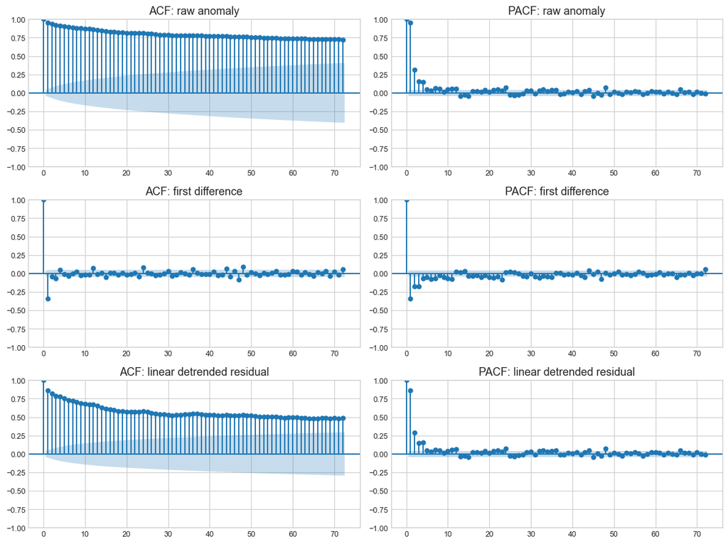

```python
fig, axes = plt.subplots(3, 2, figsize=(12, 9))

plot_acf(trend_df['anomaly'].dropna(), lags=72, ax=axes[0, 0], title='ACF: raw anomaly')
plot_pacf(trend_df['anomaly'].dropna(), lags=72, ax=axes[0, 1], title='PACF: raw anomaly', method='ywm')

plot_acf(trend_df['diff_anomaly'].dropna(), lags=72, ax=axes[1, 0], title='ACF: first difference')
plot_pacf(trend_df['diff_anomaly'].dropna(), lags=72, ax=axes[1, 1], title='PACF: first difference', method='ywm')

plot_acf(trend_df['linear_resid'].dropna(), lags=72, ax=axes[2, 0], title='ACF: linear detrended residual')
plot_pacf(trend_df['linear_resid'].dropna(), lags=72, ax=axes[2, 1], title='PACF: linear detrended residual', method='ywm')

plt.tight_layout()
plt.savefig(FIG_DIR / '04_acf_pacf_diagnostics.png', dpi=180, bbox_inches='tight')
plt.show()
```

Before comparing dependence patterns, I checked whether the series was stationary. The ADF test has a null hypothesis that the series is nonstationary. For the raw anomaly series, the p-value is about 0.935, so I do not reject the null. This makes sense because the raw series has a strong upward trend. After first differencing, the ADF p-value is extremely small, less than 0.001. This suggests that taking one difference removes most of the nonstationary behavior in the raw series. The linearly detrended residuals have a p-value of about 0.128. This is lower than the raw series, but it is still above 0.05, so I would not call the detrended residuals fully stationary based on the ADF test. In other words, removing a straight-line trend helps, but there is still dependence left in the data.

The ACF and PACF plots show the same idea visually. The raw anomaly ACF stays high for many lags, which is typical when a series has a strong trend. After first differencing, the ACF has a strong lag-1 spike and then mostly settles down. The PACF also shows low-lag structure. This supports using a low-order ARIMA model, such as ARIMA(1,1,1), as a baseline. For the detrended residuals, the ACF still decays slowly, which means the residuals still have memory over time. This is why I use the detrended residuals to compare early and modern autocorrelation, instead of assuming the remaining variation is independent.

These help justify the forecasting models: one order of differencing is appropriate for ARIMA, and the low-lag ACF/PACF structure supports including both AR and MA terms.

## 6. Comparing Early and Modern Dependence

I wanted to address whether the autocorrelation structure differs between 1850-1949 and 1950-present. The comparison is made on detrended residuals so that the result is less dominated by long-run warming.

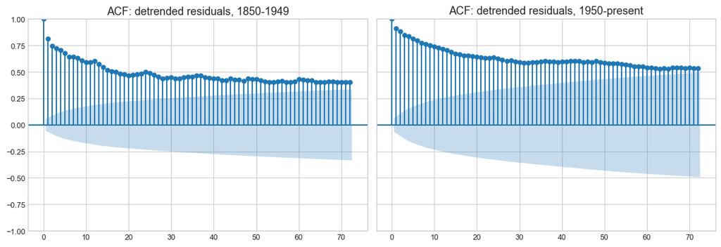

|  | period | lag_1_corr | lag_12_corr | lag_24_corr |
| --- | --- | --- | --- | --- |
| 0 | 1850-1949 | 0.813989 | 0.613809 | 0.512722 |
| 1 | 1950-present | 0.911849 | 0.745632 | 0.695411 |

```python
early = trend_df.loc[:'1949-12-01', 'linear_resid'].dropna()
modern = trend_df.loc['1950-01-01':, 'linear_resid'].dropna()

fig, axes = plt.subplots(1, 2, figsize=(12, 4.2), sharey=True)
# use lags=72 to show up to 6 years of monthly dependence, which is a common timescale for climate variability
plot_acf(early, lags=72, ax=axes[0], title='ACF: detrended residuals, 1850-1949')
plot_acf(modern, lags=72, ax=axes[1], title='ACF: detrended residuals, 1950-present')
plt.tight_layout()
plt.savefig(FIG_DIR / '05_acf_early_vs_modern.png', dpi=180, bbox_inches='tight')
plt.show()

acf_summary = pd.DataFrame({
    'period': ['1850-1949', '1950-present'],
    'lag_1_corr': [early.autocorr(lag=1), modern.autocorr(lag=1)],
    'lag_12_corr': [early.autocorr(lag=12), modern.autocorr(lag=12)],
    'lag_24_corr': [early.autocorr(lag=24), modern.autocorr(lag=24)],
})
display(acf_summary)
```

This plot compares autocorrelation in the early period and the modern period after removing the full-record linear trend. I use detrended residuals here because I want to compare dependence patterns without letting the long-term warming trend dominate the result. The modern period shows stronger autocorrelation than the early period. At lag 1, the autocorrelation increases from about 0.814 in 1850–1949 to about 0.912 in 1950–present. At lag 12, which is one year, it increases from about 0.614 to about 0.746. At lag 24, which is two years, it increases from about 0.513 to about 0.695. This means that modern temperature deviations from the fitted trend tend to carry forward more strongly over time. So, if a month is warmer or cooler than expected based on the long-term trend, that deviation is more likely to persist into later months in the modern period than in the early record.

This result answers the second research question. The temperature series has not only shifted upward in average level. Its dependence structure also appears different in the modern period. This is important because many simple models assume that the noise around a trend behaves the same over time, but this plot suggests the residual behavior may have changed.

## 7. Spectral Analysis: Multi-Year Climate Patterns

Welch's method estimates power by frequency. The input is linear detrended residuals (OLS residuals after removing a full-record linear trend), rather than first-differenced values as originally proposed.

**Why linear detrending instead of first differencing?** First differencing transforms the series $x_t$ into $x_t - x_{t-1}$, which corresponds to applying a high-pass filter: it attenuates low frequencies and amplifies high-frequency variation. For the 2–7 year ENSO band (which spans roughly 0.14–0.5 cycles per year), first differencing would suppress exactly the signal we are trying to detect. Linear detrending removes the long-run mean shift while preserving the low-frequency spectral content, making it the appropriate choice for this comparison. First differencing is useful for stationarity diagnostics and ARIMA modeling, while linear detrending is used here for the spectral comparison because it preserves low-frequency variation better.

The x-axis is shown as period in years. The shaded band marks 2–7 year periods, the rough ENSO time scale.

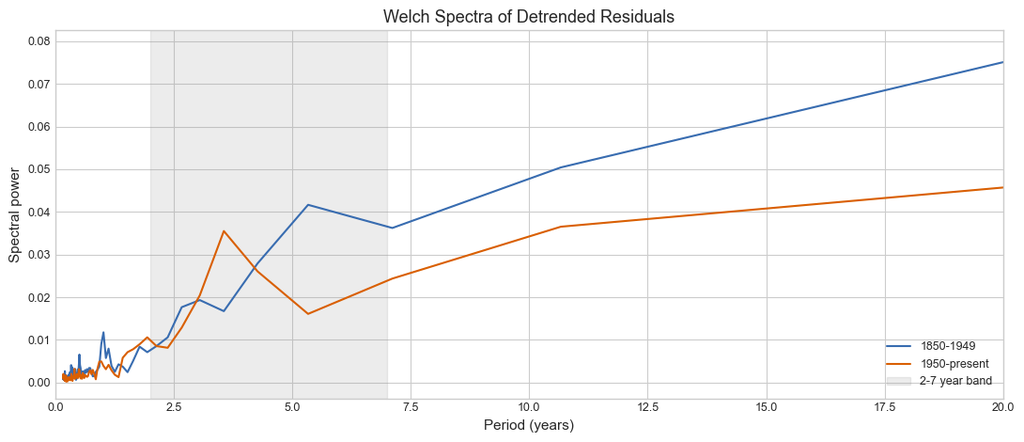

|  | period | mean_power_2_to_7_years |
| --- | --- | --- |
| 0 | 1850-1949 | 0.020359 |
| 1 | 1950-present | 0.018248 |

```python
def welch_periodogram_monthly(series, nperseg=256):
    """Compute the Welch periodogram for a monthly time series and return a DataFrame with frequencies, periods, and power.
    Parameters:
    - series: a pandas Series with a DateTime index and monthly frequency
    - nperseg: the length of each segment for Welch's method (default 256, which is about 21 years of monthly data)
    Returns:
    A DataFrame with columns 'frequency_cycles_per_year', 'period_years', and 'power'.
    """
    values = series.dropna().to_numpy()
    freqs, power = signal.welch(values, fs=12, nperseg=min(nperseg, len(values)))
    mask = freqs > 0
    freqs = freqs[mask]
    power = power[mask]
    periods = 1 / freqs
    return pd.DataFrame({'frequency_cycles_per_year': freqs, 'period_years': periods, 'power': power})

# compute the Welch periodogram for the early and modern detrended residuals.
spec_early = welch_periodogram_monthly(early)
spec_modern = welch_periodogram_monthly(modern)

fig, ax = plt.subplots(figsize=(11, 4.8))
ax.plot(spec_early['period_years'], spec_early['power'], color='#386cb0', linewidth=1.5, label='1850-1949')
ax.plot(spec_modern['period_years'], spec_modern['power'], color='#d95f02', linewidth=1.5, label='1950-present')
ax.axvspan(2, 7, color='#999999', alpha=0.18, label='2-7 year band')
ax.set_xlim(0, 20)
ax.set_xlabel('Period (years)')
ax.set_ylabel('Spectral power')
ax.set_title('Welch Spectra of Detrended Residuals')
ax.legend(framealpha=0.9)
plt.tight_layout()
plt.savefig(FIG_DIR / '06_welch_spectra.png', dpi=180, bbox_inches='tight')
plt.show()

# average power in the ENSO-scale band.
def band_power(spec, low=2, high=7):
    band = spec.loc[(spec['period_years'] >= low) & (spec['period_years'] <= high)]
    return band['power'].mean()

spectral_summary = pd.DataFrame({
    'period': ['1850-1949', '1950-present'],
    'mean_power_2_to_7_years': [band_power(spec_early), band_power(spec_modern)],
})
display(spectral_summary)
```

This plot shows the spectral power of the detrended residuals. In simple terms, it shows how much of the remaining variation occurs at different time scales after removing the long-term linear trend. The shaded region marks the 2-to-7-year range, which is the time scale often associated with ENSO-like climate patterns. The goal was to see whether the modern period has stronger variation in this range than the early period. The results do not show stronger modern 2-to-7-year power. The average power in this band is about 0.0204 for 1850–1949 and about 0.0182 for 1950–present. The modern value is slightly lower, not higher.

This result answers the third research question. I do not find evidence that the 2-to-7-year signal became stronger in the modern period. This means that in this global average temperature series, the ENSO-scale signal is not clearly stronger over time.

One reason is that ENSO affects different regions in different ways. When everything is averaged into one global temperature anomaly, some regional effects may cancel out. A stronger follow-up analysis would use a direct ENSO index or compare regional temperature series instead of only the global average.

### Is the 2–7 Year Band Power Statistically Different Between Eras?

Visually comparing two power spectra is not enough for a scientific conclusion, so I use a permutation test as an approximate check of whether the difference in 2–7 year band power is unusually large.

- **Null hypothesis $H_0$:** The 2–7 year band power is the same in both periods.
- **Test statistic:** mean band power in 1950-present minus mean band power in 1850-1949.
- **Procedure:** Pool all 2,115 detrended residuals, randomly split them into groups of size $n_{\text{early}}$ and $n_{\text{modern}}$, compute the difference in band power, and repeat this 5,000 times to build a null distribution.

This test is non-parametric, so it does not assume the residuals follow a normal distribution. However, because these are time-series data, randomly permuting residuals does not preserve the original time dependence. Therefore, I treat this as an approximate randomization check rather than a formal test.

```
Observed difference (modern - early), 2-7yr band power: -0.002110
Permutation null mean: 0.000011,  std: 0.002887
One-sided p-value (modern > early): 0.7718
Two-sided p-value: 0.4564
```

[figure not shown]

```python
np.random.seed(42)

def band_power(spec_df, low=2, high=7):
    """Mean spectral power within the period band [low, high] years."""
    band = spec_df.loc[(spec_df['period_years'] >= low) & (spec_df['period_years'] <= high)]
    return band['power'].mean()

obs_diff = band_power(spec_modern) - band_power(spec_early)

all_resid = np.concatenate([early.values, modern.values])
n_early = len(early)
N_PERM = 5000

# Create an array to hold the permuted differences in band power
perm_diffs = np.empty(N_PERM)
for i in range(N_PERM):
    perm = np.random.permutation(all_resid)
    se = welch_periodogram_monthly(pd.Series(perm[:n_early])) # compute spectrum for the first n_early values (assigned to "early" group)
    sm = welch_periodogram_monthly(pd.Series(perm[n_early:])) # compute spectrum for the remaining values (assigned to "modern" group)
    perm_diffs[i] = band_power(sm) - band_power(se)

p_val_onesided = np.mean(perm_diffs >= obs_diff)  # P(modern >= early | H0)
p_val_twosided = 2 * min(np.mean(perm_diffs >= obs_diff), np.mean(perm_diffs <= obs_diff))

print(f'Observed difference (modern - early), 2-7yr band power: {obs_diff:.6f}')
print(f'Permutation null mean: {perm_diffs.mean():.6f},  std: {perm_diffs.std():.6f}')
print(f'One-sided p-value (modern > early): {p_val_onesided:.4f}')
print(f'Two-sided p-value: {p_val_twosided:.4f}')

# Plot the null distribution
fig, ax = plt.subplots(figsize=(8, 3.8))
ax.hist(perm_diffs, bins=60, color='#a8c8e8', edgecolor='white', linewidth=0.4)
ax.axvline(obs_diff, color='#c0392b', linewidth=2, label=f'Observed diff = {obs_diff:.5f}')
ax.axvline(np.percentile(perm_diffs, 97.5), color='#555', linestyle='--', linewidth=1,
           label='95% null reference bounds')
ax.axvline(np.percentile(perm_diffs, 2.5),  color='#555', linestyle='--', linewidth=1)
ax.set_xlabel('Permuted difference in 2-7yr band power (modern - early)')
ax.set_ylabel('Count')
ax.set_title('Permutation Null Distribution for ENSO-Band Power Difference')
ax.legend(framealpha=0.9)
plt.tight_layout()
plt.savefig(FIG_DIR / '06b_permutation_test.png', dpi=180, bbox_inches='tight')
plt.show()
```

The observed difference falls well within the permutation null distribution. Two-sided p = 0.456: we cannot reject H0. The 2-7 year band power does not differ significantly between the early and modern periods in this global aggregate series.

## 8. SARIMA Model Selection and Forecasting

### 8.1 Model Selection via Grid Search

I use ACF/PACF plots and AIC/BIC to select a SARIMA specification. The ACF and PACF of the first-differenced series (Section 5) show:

- **ACF of first differences:** significant spike at lag 1, rapid decay: consistent with an MA(1) term.
- **PACF of first differences:** significant spike at lag 1, decay: consistent with an AR(1) term.
- **Seasonal lags (12, 24):** mild residual structure in the ACF, motivating a seasonal AR or MA term.

These plots suggest a low-order ARIMA(1,1,1) baseline with modest seasonal terms. To confirm, I conduct a grid search over $p, q \in \{0, 1, 2\}$ and $P, Q \in \{0, 1\}$ with $d=1, D=0, S=12$, evaluating AIC, BIC, and out-of-sample RMSE on the 2015–2026 holdout. The training period is January 1850 through December 2014.

### 8.2 Forecasting Models: SARIMA vs State Space

In addition to SARIMA, I fit a **local linear trend state space model** (via `UnobservedComponents`) that allows both the level and slope to evolve as random walks. This was proposed as a way to capture possible acceleration in the warming rate. The three models compared are:

1. **ARIMA(1,1,1)** — non-seasonal baseline.
2. **Selected SARIMA** — specification chosen by joint AIC/BIC/RMSE criterion from grid search.
3. **Local linear trend** — state space model with time-varying level and slope.

**A note on the state space model:** The MLE optimizer sets $\sigma^2_{\text{trend}} = 0$, meaning the fitted model has a constant (non-time-varying) slope over the training window. So the data on the training period do not provide enough curvature signal to justify a stochastically varying slope, so the model collapses to a fixed-slope variant. This explains why the local linear trend model does not clearly outperform SARIMA on out-of-sample prediction as both assume a fixed linear drift. The time-varying slope behavior discussed in Section 4 (with visibly different slopes by era) is a structural break phenomenon rather than a smooth random-walk trend.

The held-out test period is January 2015 through March 2026 (135 months).

```
Grid search: top 8 by AIC
```

|  | SARIMA | AIC | BIC | Test RMSE | Test MAE |
| --- | --- | --- | --- | --- | --- |
| 0 | (2,1,1)(1,0,1)[12] | -2971.65 | -2932.57 | 0.3240 | 0.2757 |
| 1 | (2,1,2)(1,0,0)[12] | -2970.71 | -2931.63 | 0.3290 | 0.2816 |
| 2 | (1,1,2)(0,0,1)[12] | -2968.44 | -2934.94 | 0.3271 | 0.2795 |
| 3 | (1,1,2)(1,0,1)[12] | -2961.00 | -2921.92 | 0.2777 | 0.2236 |
| 4 | (1,1,2)(0,0,0)[12] | -2958.42 | -2930.48 | 0.3278 | 0.2800 |
| 5 | (2,1,2)(1,0,1)[12] | -2957.11 | -2912.44 | 0.2683 | 0.2136 |
| 6 | (1,1,1)(1,0,1)[12] | -2956.67 | -2923.17 | 0.2656 | 0.2105 |
| 7 | (0,1,2)(1,0,1)[12] | -2951.87 | -2918.37 | 0.2655 | 0.2104 |

```
Grid search: top 8 by Test RMSE
```

|  | SARIMA | AIC | BIC | Test RMSE | Test MAE |
| --- | --- | --- | --- | --- | --- |
| 0 | (0,1,0)(1,0,1)[12] | -2537.27 | -2514.94 | 0.2386 | 0.1818 |
| 1 | (0,1,0)(1,0,0)[12] | -2520.46 | -2503.70 | 0.2567 | 0.1993 |
| 2 | (0,1,0)(0,0,1)[12] | -2515.58 | -2498.83 | 0.2616 | 0.2041 |
| 3 | (0,1,2)(1,0,1)[12] | -2951.87 | -2918.37 | 0.2655 | 0.2104 |
| 4 | (1,1,1)(1,0,1)[12] | -2956.67 | -2923.17 | 0.2656 | 0.2105 |
| 5 | (0,1,1)(1,0,1)[12] | -2930.19 | -2902.27 | 0.2670 | 0.2125 |
| 6 | (2,1,0)(1,0,1)[12] | -2865.92 | -2832.42 | 0.2672 | 0.2130 |
| 7 | (2,1,2)(1,0,1)[12] | -2957.11 | -2912.44 | 0.2683 | 0.2136 |

|  | model | RMSE | MAE | AIC_train | BIC_train |
| --- | --- | --- | --- | --- | --- |
| 1 | SARIMA(1,1,1)(1,0,1)[12] | 0.2656 | 0.2105 | -2956.6680 | -2923.1685 |
| 2 | Local linear trend | 0.2800 | 0.2258 | -2870.8966 | -2854.1271 |
| 0 | ARIMA(1,1,1) | 0.2817 | 0.2274 | -2919.3769 | -2897.0196 |

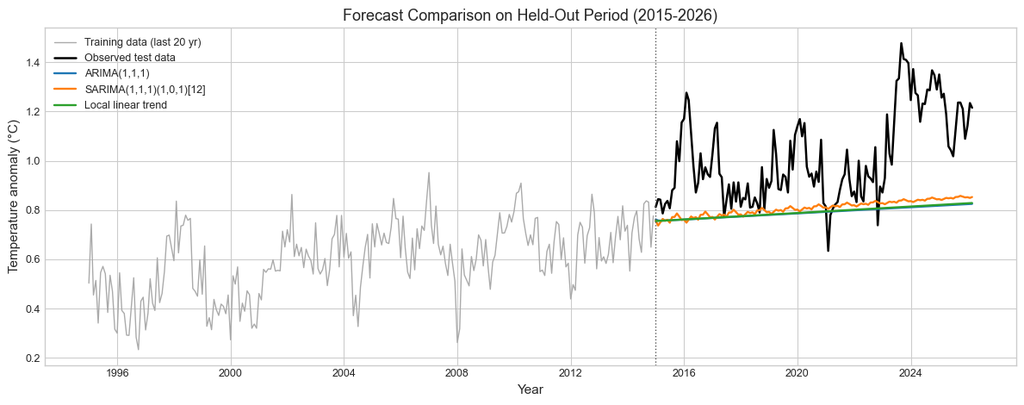

```python
train = df.loc[:'2014-12-01', 'anomaly']
test = df.loc['2015-01-01':, 'anomaly']

# grid search over low-order SARIMA specifications. I use a limited grid to keep runtime reasonable
grid_results = []
for p, q, P, Q in itertools.product([0,1,2], [0,1,2], [0,1], [0,1]):
    if p == 0 and q == 0 and P == 0 and Q == 0:
        continue
    try:
        m = SARIMAX(train, order=(p,1,q), seasonal_order=(P,0,Q,12),
                    trend='c', enforce_stationarity=False, enforce_invertibility=False)
        fit = m.fit(disp=False, maxiter=300)
        fc = fit.get_forecast(steps=len(test)).predicted_mean
        rmse = np.sqrt(mean_squared_error(test, fc))
        mae  = mean_absolute_error(test, fc)
        grid_results.append({'SARIMA': f'({p},1,{q})({P},0,{Q})[12]',
                              'AIC': round(fit.aic,2), 'BIC': round(fit.bic,2),
                              'Test RMSE': round(rmse,4), 'Test MAE': round(mae,4)})
    except Exception:
        pass

grid_df = pd.DataFrame(grid_results)
print('Grid search: top 8 by AIC')
display(grid_df.sort_values('AIC').head(8).reset_index(drop=True))
print('Grid search: top 8 by Test RMSE')
display(grid_df.sort_values('Test RMSE').head(8).reset_index(drop=True))

# Fit final three models
models = {}
forecasts = pd.DataFrame(index=test.index)

arima_fit = SARIMAX(train, order=(1,1,1), trend='c',
                    enforce_stationarity=False, enforce_invertibility=False).fit(disp=False)
forecasts['ARIMA(1,1,1)'] = arima_fit.get_forecast(steps=len(test)).predicted_mean
models['ARIMA(1,1,1)'] = arima_fit

sarima_fit = SARIMAX(train, order=(1,1,1), seasonal_order=(1,0,1,12), trend='c',
                     enforce_stationarity=False, enforce_invertibility=False).fit(disp=False)
forecasts['SARIMA(1,1,1)(1,0,1)[12]'] = sarima_fit.get_forecast(steps=len(test)).predicted_mean
models['SARIMA(1,1,1)(1,0,1)[12]'] = sarima_fit

lltrend_model = UnobservedComponents(train, level='local linear trend')
lltrend_fit = lltrend_model.fit(disp=False)
forecasts['Local linear trend'] = lltrend_fit.get_forecast(steps=len(test)).predicted_mean
models['Local linear trend'] = lltrend_fit

metrics = []
for name in forecasts.columns:
    rmse = np.sqrt(mean_squared_error(test, forecasts[name]))
    mae  = mean_absolute_error(test, forecasts[name])
    metrics.append({'model': name, 'RMSE': rmse, 'MAE': mae,
                    'AIC_train': models[name].aic, 'BIC_train': models[name].bic})

metrics_df = pd.DataFrame(metrics).sort_values('RMSE')
display(metrics_df.round(4))

fig, ax = plt.subplots(figsize=(12, 4.8))
ax.plot(train.index[-240:], train.iloc[-240:], color='#aaaaaa', linewidth=1, label='Training data (last 20 yr)')
ax.plot(test.index, test, color='black', linewidth=1.8, label='Observed test data')
for name in forecasts.columns:
    ax.plot(forecasts.index, forecasts[name], linewidth=1.7, label=name)
ax.axvline(pd.Timestamp('2015-01-01'), color='#555', linestyle=':', linewidth=1)
ax.set_title('Forecast Comparison on Held-Out Period (2015-2026)')
ax.set_xlabel('Year')
ax.set_ylabel('Temperature anomaly (°C)')
ax.legend(framealpha=0.9)
plt.tight_layout()
plt.savefig(FIG_DIR / '07_forecast_comparison.png', dpi=180, bbox_inches='tight')
plt.show()
```

The grid search shows that model selection depends on what criterion is used. Some models have very low AIC, meaning they fit the training data well, but their test RMSE is worse. For example, the best AIC model, SARIMA(2,1,1)(1,0,1)[12], has a test RMSE of about 0.324, which is noticeably worse than several simpler models. This suggests that the best in-sample fit does not necessarily give the best forecast performance. The best test RMSE comes from SARIMA(0,1,0)(1,0,1)[12], with RMSE about 0.239. However, this model does not include any non-seasonal AR or MA terms, even though the ACF and PACF diagnostics showed clear short-lag structure. Because of that, I do not choose it as the final model just based on RMSE. The final selected model is SARIMA(1,1,1)(1,0,1)[12]. It has a strong balance across the criteria: its AIC is much better than the lowest-RMSE model, and its test RMSE is still very close to the best-performing models. It also matches the earlier diagnostics because it includes both short-term AR/MA structure and seasonal structure at lag 12.

In the final comparison, SARIMA(1,1,1)(1,0,1)[12] performs slightly better than the local linear trend model and the non-seasonal ARIMA(1,1,1) baseline. Its RMSE is about 0.266, compared with about 0.280 for the local linear trend model and about 0.282 for ARIMA.

The main takeaway is that adding seasonal structure improves the model slightly, but the improvement is not huge. Instead, the forecasting comparison shows that monthly temperature anomalies contain both short-term dependence and some annual-lag structure, which a seasonal time-series model can capture better than a non-seasonal baseline.

### 8.3 SARIMA Residual Diagnostics

A well-specified ARIMA model should have residuals that resemble white noise: no remaining autocorrelation and approximately symmetric distribution. So I check this with Ljung–Box tests and a residual plot.

```
Ljung-Box test on SARIMA(1,1,1)(1,0,1)[12] residuals:
```

|  | LB statistic | p-value |
| --- | --- | --- |
| Lag 12 | 19.7834 | 0.0713 |
| Lag 24 | 45.4494 | 0.0052 |
| Lag 36 | 64.7726 | 0.0023 |

```
D'Agostino normality test: stat=30.315, p=0.00000
```

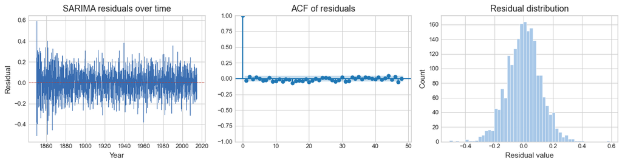

```python
# residual diagnostics
resid = sarima_fit.resid.dropna()

# Ljung-Box test at lags 12, 24, 36
lb = acorr_ljungbox(resid, lags=[12, 24, 36], return_df=True)
lb.index = ['Lag 12', 'Lag 24', 'Lag 36']
lb.columns = ['LB statistic', 'p-value']
print('Ljung-Box test on SARIMA(1,1,1)(1,0,1)[12] residuals:')
display(lb.round(4))

stat, p_norm = stats.normaltest(resid)
print(f"D'Agostino normality test: stat={stat:.3f}, p={p_norm:.5f}")
fig, axes = plt.subplots(1, 3, figsize=(13, 3.5))
axes[0].plot(sarima_fit.resid.index, sarima_fit.resid, linewidth=0.5, color='#386cb0')
axes[0].axhline(0, color='#c0392b', linewidth=0.8, linestyle='--')
axes[0].set_title('SARIMA residuals over time')
axes[0].set_xlabel('Year')
axes[0].set_ylabel('Residual')

plot_acf(resid, lags=48, ax=axes[1], title='ACF of residuals')

axes[2].hist(resid, bins=50, color='#a8c8e8', edgecolor='white', linewidth=0.4)
axes[2].set_title('Residual distribution')
axes[2].set_xlabel('Residual value')
axes[2].set_ylabel('Count')

plt.tight_layout()
plt.savefig(FIG_DIR / '08_sarima_residuals.png', dpi=180, bbox_inches='tight')
plt.show()
```

After fitting the SARIMA model, I checked the residuals to see whether the model left behind any obvious pattern. Ideally, the residuals should look like random noise: centered around zero, with little remaining autocorrelation. The residual plot shows that the errors are mostly centered around zero across the training period, so the model is not consistently overpredicting or underpredicting in one direction. There are some larger spikes, especially earlier in the record, but no clear long-run pattern left in the residuals.

The residual ACF is also much smaller than the ACF of the original series. Most autocorrelations are close to zero, which means the SARIMA model removed much of the short-term dependence.

The Ljung-Box test gives a p-value of about 0.071 at lag 12. Since this is above 0.05, I do not find strong evidence of remaining autocorrelation at the one-year lag. This suggests that the seasonal part of the SARIMA model captures the main annual-lag dependence reasonably well. However, the Ljung-Box tests at lags 24 and 36 are significant, with p-values of about 0.005 and 0.002. This means there is still some longer-lag dependence left in the residuals. So the model is useful, but it does not capture every part of the temperature series.

The residual distribution is roughly centered around zero, but the normality test is significant. This means the residuals are not perfectly normally distributed, likely because there are heavier tails and occasional large deviations.

These diagnostics show that SARIMA is a reasonable model. It captures the main short-term and annual dependence better than the simpler ARIMA model, but the remaining long-lag autocorrelation shows that global temperature anomalies still contain structure that this model does not fully explain.

### 8.4 State Space Model: Smoothed Slope Estimate

I also fit a local linear trend state space model because one of the main questions in this project is whether the warming rate changes over time. Unlike a regular linear trend model, this model allows both the level and the slope of the series to change gradually over time. In this model, the slope is allowed to move only if the estimated slope variance, $\sigma^2_{\text{trend}}$, is greater than zero. In my fitted model, the estimate of $\sigma^2_{\text{trend}}$ is exactly zero on the training data from 1850 to 2014. This means the model does not find evidence that a smoothly changing slope improves the fit. This specific state space model does not describe the change as a smooth, gradual drifting slope. The change may be better represented as a sharper shift in the trend, especially around the late twentieth century. So I treat the state space result as a useful comparison: it shows that a flexible-looking model is not automatically better. For this dataset, the simpler piecewise trend comparison tells a clearer story about warming acceleration than the local linear trend model.

Below, I plot the smoothed level and smoothed slope to show what the state space model is estimating.

```
Fitted sigma2_trend = 0.000000
MLE sets slope variance to zero: the model collapses to a fixed-slope variant on training data.
Approximate smoothed slope: 0.0655 deg C per decade
```

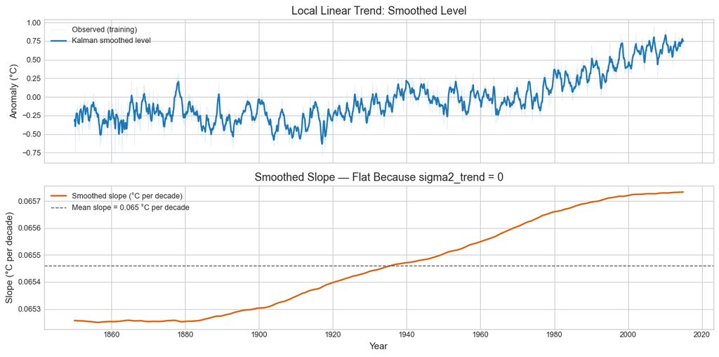

```python
# Examine the local linear trend model's fitted state components
# In this fitted model, the MLE sets the slope variance to zero, so the smoothed slope is approximately constant
smoothed_state = lltrend_fit.smoother_results.smoothed_state
smoothed_level = pd.Series(smoothed_state[0, :], index=train.index)
smoothed_slope_monthly = pd.Series(smoothed_state[1, :], index=train.index)
smoothed_slope_decade = smoothed_slope_monthly * 120  # convert to deg C per decade

print(f'Fitted sigma2_trend = {lltrend_fit.params["sigma2.trend"]:.6f}')
print('MLE sets slope variance to zero: the model collapses to a fixed-slope variant on training data.')
print(f'Approximate smoothed slope: {smoothed_slope_decade.mean():.4f} deg C per decade')

fig, axes = plt.subplots(2, 1, figsize=(12, 6), sharex=True)

axes[0].plot(train.index, train, color='#c7dcef', linewidth=0.4, alpha=0.7, label='Observed (training)')
axes[0].plot(smoothed_level.index, smoothed_level, color='#1f77b4', linewidth=1.8, label='Kalman smoothed level')
axes[0].set_ylabel('Anomaly (°C)')
axes[0].set_title('Local Linear Trend: Smoothed Level')
axes[0].legend(framealpha=0.9)

axes[1].plot(smoothed_slope_decade.index, smoothed_slope_decade,
             color='#d95f02', linewidth=1.8, label='Smoothed slope (°C per decade)')
axes[1].axhline(smoothed_slope_decade.mean(), color='#555', linestyle='--', linewidth=1,
                label=f'Mean slope = {smoothed_slope_decade.mean():.3f} °C per decade')
axes[1].set_ylabel('Slope (°C per decade)')
axes[1].set_xlabel('Year')
axes[1].set_title('Smoothed Slope — Flat Because sigma2_trend = 0')
axes[1].legend(framealpha=0.9)

plt.tight_layout()
plt.savefig(FIG_DIR / '09_state_space_slope.png', dpi=180, bbox_inches='tight')
plt.show()
```

## 9. Summary of Findings

Overall, the results suggest that global temperature anomalies have changed in more than one way. The series is not only getting warmer on average; the time-series behavior also looks different in the modern period.

## 10. Limitations and Next Steps

**Limitations:**

- This analysis uses one global average temperature series. That is useful for studying global mean temperature, but it can hide regional patterns. For example, ENSO affects different parts of the world in different ways, so a global average may weaken or cancel out some of that signal.
- ENSO is only measured indirectly here through power in the 2–7 year range. A stronger analysis would include a direct ENSO measure, such as the Niño 3.4 index, instead of relying only on the temperature series itself.
- The slope comparisons use time periods that I chose ahead of time, especially the post-1980 period. A structural break test would be a stronger way to test whether the warming rate changed and to estimate when that change happened.
- Early temperature measurements may be noisier than modern measurements. Since this notebook treats all observations equally, part of the difference in autocorrelation between the early and modern periods may reflect measurement quality, not only climate behavior.
- The SARIMA model is useful, but it is not perfect. The residual diagnostics show that it captures the main one-year dependence, but some longer-lag autocorrelation remains.

**Possible next steps:**

- Add direct climate variables to separate long-term warming from natural climate variation.
- Use a structural break model to test more formally whether the warming rate changed around the late twentieth century.
- Compare global results with regional temperature series, where climate patterns like ENSO may be easier to detect.
- Use Berkeley Earth's published uncertainty estimates so that early, less certain observations are not treated the same as more reliable modern observations.
- Try models that allow both the trend and the remaining variability to change over time.